# Befolkningsutvecklingen i Smedjebacken

Befolkningsutvecklingen i Smedjebacken  
- en kort analys

Rapporten är skapad av Samhällsanalys, Region Dalarna  
Senast uppdaterad: 2026-05-16

# Sammanfattning

Syftet med den här korta analysen är att undersöka Smedjebackens befolkningsutveckling. Ett antal viktiga slutsatser sammanfattas här:

- Smedjebackens folkmängd minskade med 65 personer år 2025, men minskningen var lägre än föregående år.
- Det föddes färre barn i Smedjebacken 2025, jämfört med åren innan. Sjunkande födelsetal är en nationell trend men också en trend i de flesta av världens utvecklade länder.
- Fler personer flyttade till än från Smedjebacken 2025, vilket var en tydlig förändring jämfört med året innan när nettot var negativt.

För mer info om statistiken, klicka på rutan nedan:

**Mer information om statistiken**

I folkmängden som SCB publicerar ingår personer som är folkbokförda i landet. För att den som flyttar till Sverige ska bli folkbokförd ska personen ha för avsikt och rätt att stanna i Sverige i minst ett år. För personer som inte är medborgare i ett EU-land innebär det att det krävs ett uppehållstillstånd som gäller minst 12 månader för att bli folkbokförd. Till följd av Rysslands invasion av Ukraina den 24 februari 2022 har Europeiska unionen (EU) beslutat att aktivera massflyktsdirektivet, vilket innebär att personer från Ukraina utan individuell prövning ska erbjudas tidsbegränsat uppehålls- och arbetstillstånd inom EU. Personer som får uppehållstillstånd enligt massflyktsdirektivet ska i regel inte bli folkbokförda och ingå i den officiella befolkningsstatistiken. Läs mer här. Sedan juni 2024 har dock personer födda i Ukraina haft möjlighet att ansöka om att bli folkbokförda i Sverige (SCB).

Under 2023 inledde Skatteverket ett arbete med att granska registret över folkbokförda. Det förde med sig att SCB avregistrerade flera tusen folkbokförda personer som visade sig inte längre bo i Sverige. I folkbokföringen har dessa registrerats som utvandrade till okänt utvandringsland. Detta arbete fortsatte under 2024. Läs mer [här](https://www.scb.se/pressmeddelande/sverige-gar-mot-lagsta-befolkningsokningen-pa-manga-ar/).

All data som används i rapporten är offentlig och finns under kategorin befolkning i SCB:s [Statistikdatabas](https://www.statistikdatabasen.scb.se/pxweb/sv/ssd/). Där finns även data för exempelvis befolkningsutvecklingen under 2025 på månadsbasis som publiceras löpande, något som inte behandlas i denna rapport.

Från och med referensåret 2025 och framåt är en liten kontrollerad slumpmässig osäkerhet införd i samtliga redovisade uppgifter. Osäkerheten har tillförts för att skydda enskilda personer så att ingen riskerar att röjas i statistiken. Till följd av detta så är inte alltid de redovisade totalerna lika med summan av deras redovisade delar.

Om redovisade statistikvärden adderas för att skapa en ny total, så adderas även osäkerheten. Det finns därför risk för att den nya totalen innehåller större osäkerhet än vad som, enligt metoden, skulle ha tillförts ett enskilt statistikvärde.

Metoden som används för röjandekontroll heter Cell Key Method (CKM). Du kan läsa mer om metoden här: [Skyddsmetoder för röjandekontroll](https://www.scb.se/dokumentation/statistiska-metoder/skyddsmetoder-for-rojandekontroll/) och här: [utveckling av röjandeskyddet](https://www.scb.se/dokumentation/statistikomraden-under-forandring/utveckling-av-rojandeskyddet/), samt i befolkningsstatistikens dokumentation (kvalitetsdeklarationen, avsnitt 2.2.6).

FAQ om CKM-metoden hittar du här: [Frågor och svar om röjandeskydd i befolkningsstatistiken](https://www.scb.se/FAQ-CKM)

# 1 Hur har befolkningen förändrats?

I likhet med flera andra bruksorter i de södra delarna av Dalarna har befolkningen i Smedjebacken minskat på lång sikt, från ca 12 700 invånare år 1968 till ungefär 10 800 invånare år 2025.

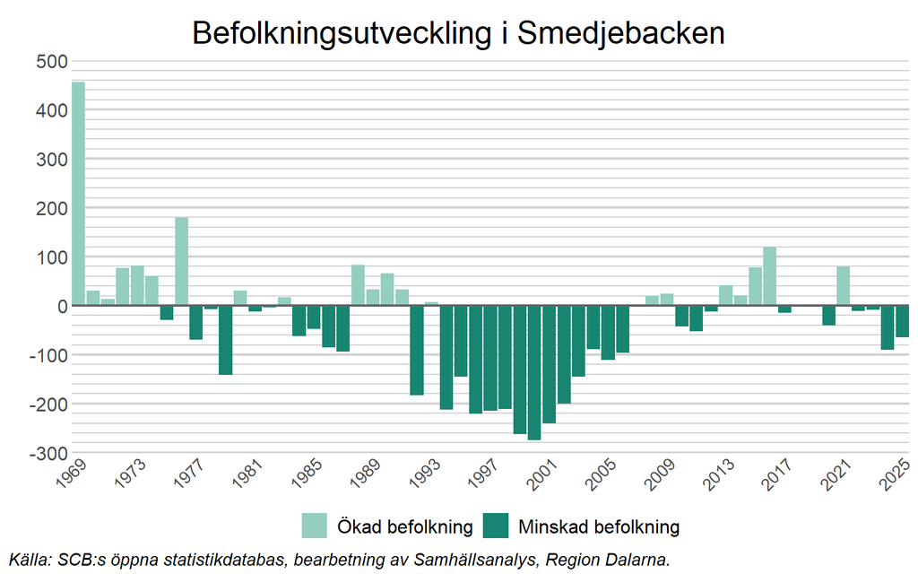

I fortsättningen av denna korta analys delas befolkningsutveckling upp i dess komponenter, födelsenetto, dvs. nettot av födda och döda, och flyttnetto, dvs. nettot av inrikes och utrikes flyttar.

# 2 Födelsenetto

En trend är att det dör färre personer boende i Smedjebacken idag än det gjorde längre tillbaka i tiden. Visserligen dog relativt många under Corona-pandemin och något år dessförinnan, men de senaste åren har mellan 120 och 130 personer dött årligen i kommunen, jämfört med ofta över 150 personer under exempelvis 1990-talet. Detta hör delvis samman med att folkmängden idag är mindre, men den främsta orsaken är sannolikt utveckling inom det medicinska området. Befolkningens medelålder ökar över tid och har gjort så länge.

Även när det gäller antalet födslar är trenden negativ. Under tidigt 1990-tal föddes ofta över 150 barn i Smedjebacken per år, men en tydlig negativ trend inleddes i samband med finanskrisen i början på 1990-talet, när befolkningen också minskade kraftigt. Under 2010-talet ökade födslarna igen, något som sannolikt har att göra med att Smedjebackens befolkning då ökade till följd av högre invandring. År 2025 föddes knappt 60 barn, vilket var tydligt färre än åren innan.

Med undantag för 2015, har nettot mellan födda och döda, se de svarta linjerna i diagrammet nedan, varit negativt i Smedjebacken under varje år sedan mitten av 1990-talet. Hur många invånare som kommunen tappar på grund av det varierar relativt mycket mellan åren.

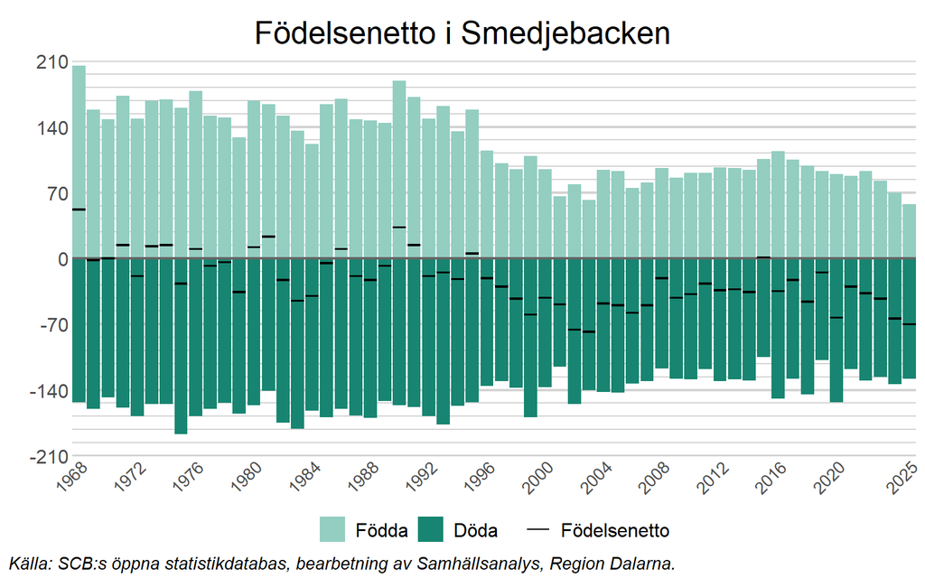

# 3 Flyttnetto

Den andra komponenten som styr befolkningsutvecklingen är det så kallade flyttnettot. Detta kan i sin tur delas upp i två komponenter, inrikes och utrikes flyttar. I det här avsnittet är fokus först på flyttnettot, innan de två komponenterna undersöks.

Nettot mellan antalet personer som flyttar till och från Smedjebacken varierar relativt mycket mellan åren, men har sedan mitten av 00-talet ofta varit positivt. Framförallt flyttade många till kommunen under 2016 och några år dessförinnan, men även under andra hälften av 00-talet var det en relativt stor inflyttning. År 2021 flyttade många till Smedjebacken, vilket möjligtvis kan hänga samman med Corona-pandemin.

Efter att ha varit tydligt negativt 2024, var flyttnettot återigen positivt 2025.

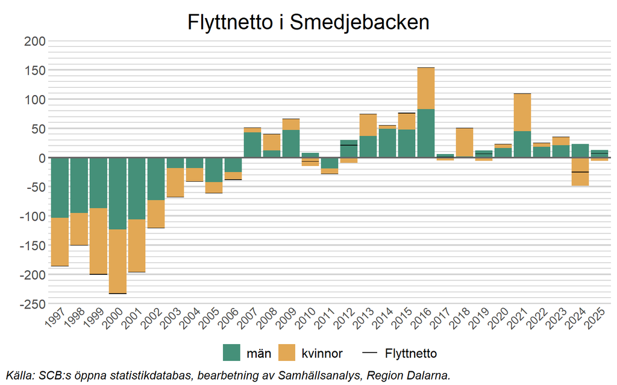

## 3.1 Utrikes flyttnetto

Som berördes i föregående avsnitt, flyttade många till Smedjebacken under framförallt 2016, vilket till stor del kan förklaras av att invandringen då var stor. Under åren runt millennieskiftet var invandringen ofta väldigt låg och till och med negativ under något år (fler utvandrade än invandrade), men därefter skedde en ökning innan den stora toppen 2016. Med undantag för 2018, när invandringen var relativt hög, har den därefter minskat tydligt, vilket sannolikt hör samman med en tydligt stramare nationell migrationspolitik.

År 2025 var det utrikes flyttnettot till kommunen positivt, men klart lägre än åren innan.

Värt att notera är att Skattemyndigheten under 2023 påbörjade en avregistrering av utvandrade, vilket kan få viss påverkan på utvandringen åtminstone 2023 och 2024 (se informationsrutan under avsnittet introduktion ovan).

Generellt invandrar ungefär lika många kvinnor och män till Smedjebacken.

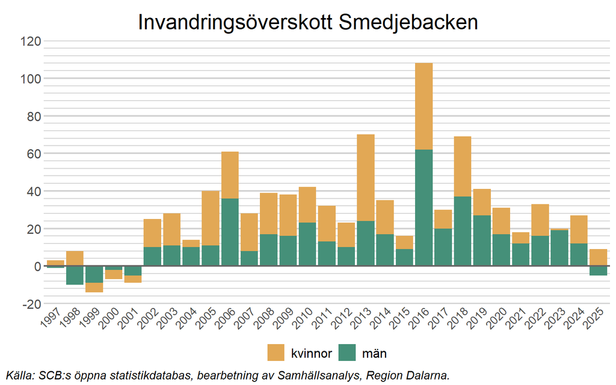

## 3.2 Inrikes flyttnetto

Utvecklingen för det inrikes flyttnettot följer i mångt och mycket Smedjebackens befolkningsutveckling i stort. Under perioden efter finanskrisen i början av 1990-talet till mitten av 00-talet, flyttade många från kommunen till andra delar av Sverige. Sedan dess har det inrikes flyttnettot varierat relativt mycket mellan åren, med omväxlande positiva och negativa netton. Under 2015 och 2016 flyttade förhållandevis många till kommunen inrikes, medan de skedde en utflyttning (netto) under åren därefter, troligtvis på grund av att personer som invandrat till kommunen valde att flytta till andra delar av Sverige av olika anledningar. År 2021 var ett exceptionellt år för Smedjebacken, då närmare 100 personer netto flyttade till kommunen inrikes. Exakt vad det beror på är svårt att veta, men det skulle möjligtvis kunna ha något att göra med corona-pandemin.

År 2025 var det inrikes flyttnettot mer eller mindre oförändrat, vilket var en tydlig förändring jämfört med året innan när nettot var tydligt negativt.

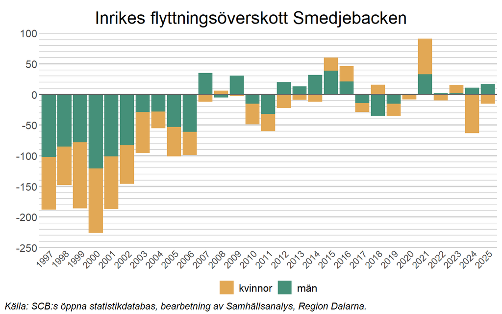

I nästa avsnitt är fokus istället på framtiden. Hur kommer Smedjebackens folkmängd att utvecklas fram till 2034?

# 4 Vad händer i framtiden?

*Notera att prognosen nedan gjordes våren 2025. Avsnittet kommer därför att uppdateras med en ny prognos under våren 2026.*

För en djupare förståelse runt hur Region Dalarna gör befolkningsprognoser, se motsvarande avsnitt i rapporten för hela Dalarnas län. Det viktigaste att ha i åtanke är att ingen hänsyn tas i prognoserna till exempelvis företagsetableringar eller andra framtida mål och förutsättningar som kommunerna har i sina planer.

I diagrammet nedan visas befolkningsutvecklingen i Smedjebacken fram till 2034 uppdelat på åldersgrupper, enligt Region Dalarnas prognos från våren 2025.

- Folkmängden i Smedjebacken prognostiseras att minska till 10 280 personer år 2034, en minskning med ungefär 540 personer jämfört med 2024. I SCB:s senaste prognos (juni 2024), prognostiserades en befolkning på drygt 10 570 personer i Smedjebacken år 2034 (se [SCB, 2024](https://www.statistikdatabasen.scb.se/pxweb/sv/ssd/START__BE__BE0401__BE0401A/BefProgRegFakN/)).
- Den största minskningen sker bland barn och unga, 0-19 år, som prognostiseras minska med ungefär 390 personer.
- I åldergruppen 80+ förväntas befolkning att öka med 250 personer fram till 2034. Detta hänger sannolikt samman med att den förväntade livslängden fortsätter öka och att den stora gruppen “baby-boomers” börjar komma upp i 80-års åldern.
- Även i gruppen som brukar benämnas arbetsför ålder, 20-65 år, sker en relativt stor minskning av befolkningen, ungefär 320 personer.

[figure not shown]